# The RVS (Rare Variant Sharing) Package

Alexandre Bureau, Ingo Ruczinski, Samuel Younkin, Thomas Sherman

#### Package version: RVsharing2 1.99.0

# 1 Introduction

The primary use of the *RVS* package is to compute the rare variant sharing probabilities outlined in Bureau et al. (2014).

# 2 Pedigree format

The main input used in this package is a *Pedigree* object from the *kinship2* package on CRAN (Therneau et al. (2015)). The package vignette (https://cran.r-project.org/web/packages/kinship2/vignettes/pedigree.pdf) outlines the basic steps to creating a *Pedigree*. Only the *id*, *findex*, *mindex* fields are necessary for computing sharing probabilities. The *RVS* package comes with 8 sample pedigrees.

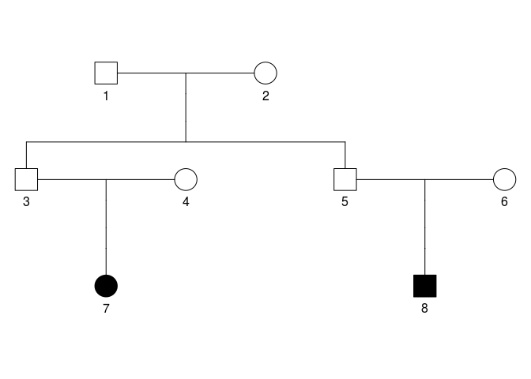

```r
data(samplePedigrees) # load sample pedigrees
kinship2::plot.pedigree(samplePedigrees$firstCousinPair) # plot pedigree
```

# 3 Computing Standard Sharing Probabilities

The primary function for computing sharing probabilities is *RVsharing*. There are two simple cases in which the calculation is straightforward.

## 3.1 Assuming One Founder Introduces the Variant

In this case, we assume the variant is rare enough so that the probability of more than one founder introducing it to the pedigree is negligible. This is the default scenario for *RVsharing*.

```r
RVsharing(samplePedigrees$firstCousinPair)
```

```
## Probability subjects 7 8 among 7 8 share a rare variant: 0.0667
```

```
## [1] 0.06666667
```

## 3.2 When Allele Frequency is Known in the Founder Population

In this case, we know the allele freqeuncy of the rare variant in the population the founders are drawn from. This allows for quick, exact calculation of the sharing probability. To specify the allele frequency, use the argument *alleleFreq*.

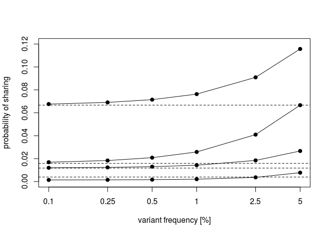

```r
defaultProbs <- sapply(samplePedigrees[1:4], function(p) suppressMessages(RVsharing(p)))

exactProbs <- list()
freq <- c(0.001,0.0025,0.005,0.01,0.025,0.05)
exactProbs$fistCousinPair <- sapply(freq, function(f) suppressMessages(RVsharing(samplePedigrees$firstCousinPair, alleleFreq=f)))
exactProbs$secondCousinPair <- sapply(freq, function(f) suppressMessages(RVsharing(samplePedigrees$secondCousinPair, alleleFreq=f)))
exactProbs$firstCousinTriple <- sapply(freq, function(f) suppressMessages(RVsharing(samplePedigrees$firstCousinTriple, alleleFreq=f)))
exactProbs$secondCousinTriple <- sapply(freq, function(f) suppressMessages(RVsharing(samplePedigrees$secondCousinTriple, alleleFreq=f)))

plot(NULL, xlim=c(0.001,0.05), ylim=c(0,0.12),log='x',xaxt='n', ylab='probability of sharing', xlab='variant frequency [%]')
axis(side=1, at=freq, labels=freq*100)
invisible(sapply(exactProbs, lines, x=freq))
invisible(sapply(exactProbs, points, x=freq, pch=19))
abline(h=defaultProbs,lty=2)
```

Similiar to Figure 2 in Bureau et al. (2014)

## 3.3 Sharing Probabilties in a Subset of a Pedigree

By default, *RVsharing* will compute the probability that all of the final descendants share the variant given that it is seen in at least one of them. Final descendants are defined as subjects of the pedigree with no children. This event can be customized with the *carriers* and *useAffected* arguments.

If the argument *carriers* is provided, then the probability of all carriers having the variant given it is seen in at least one final descendant will be computed.

If the argument *useAffected* is TRUE and the pedigree has a slot for *affected*, then the probability of all carriers having the variant given it is seen in at least one affected will be computed.

These two arguments can be used individually or in combination, the only restriction is that carriers must be a subset of affected.

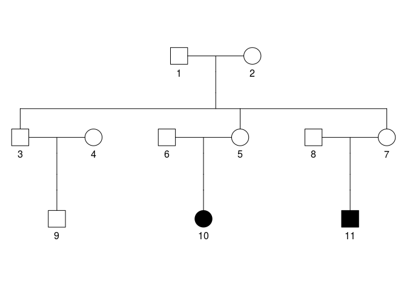

```r
ped <- samplePedigrees$firstCousinTriple
ped$affected[9] <- 0
plot(ped)
```

```r
p <- RVsharing(ped)
```

```
## Probability subjects 9 10 11 among 9 10 11 share a rare variant: 0.0118
```

```r
p <- RVsharing(ped, useAffected=TRUE)
```

```
## Probability subjects 10 11 among 10 11 share a rare variant: 0.0667
```

```r
p <- RVsharing(ped, carriers=c(9,10))
```

```
## Probability subjects 9 10 among 9 10 11 share a rare variant: 0.0353
```

```r
p <- RVsharing(ped, carriers=c(10,11), useAffected=TRUE)
```

```
## Probability subjects 10 11 among 10 11 share a rare variant: 0.0667
```

# 4 Correcting for Related Founders

When founders of the pedigree are related, the computation is more tricky. *RVsharing* allows the user to apply a correction for this fact in two different ways. The first way, explained below, is a method from Bureau et al. (2014) that uses the mean kinship ceofficient among founders to apply a correction. More detailed corrections can be made when doing a monte carlo simulation, and that method is outlined in the following section.

## 4.1 Exact Computation with Kinship Coefficient

In this method, a mean kinship coefficient among the founders is passed in with the *kinshipCoeff* parameter. Using the methods from Bureau et al. (2014), *RVsharing* then computes the sharing probability on the assumption one or two founders introduce the variant. Weighing each probability using a calculation based on the mean kinship coefficient.

```r
p <- RVsharing(samplePedigrees$firstCousinPair)
```

```
## Probability subjects 7 8 among 7 8 share a rare variant: 0.0667
```

```r
p <- RVsharing(samplePedigrees$firstCousinPair, kinshipCoeff = 0.05)
```

```
## Probability subjects 7 8 among 7 8 share a rare variant: 0.1439
```

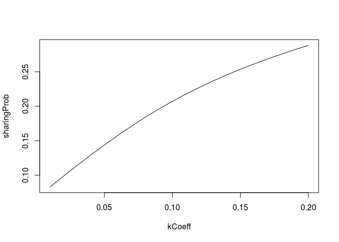

```r
kCoeff <- seq(0.01,0.2,0.01)
sharingProb <- sapply(kCoeff, function(c) suppressMessages(RVsharing(samplePedigrees$firstCousinPair, kinshipCoeff=c)))
plot(kCoeff, sharingProb, type='l')
```

## 4.2 Estimating Mean Kinship Coefficient Among Founders

Given the observed kinship between two subjects, $\hat{\phi}_{i,j}$, and the expected kinship , $\phi^p_{i,j}$, it is possible to estimate the mean kinship among the founders, $\hat{\phi^f}_{i,j}$. Averaging this estimate over all sequenced subjects gives a global estimate for the mean kinship coefficient. The relationship is given by:

$\hat{\phi^f}_{i,j} \kappa_{i,j} = \hat{\phi}_{i,j} - \phi^p_{i,j}$

Where $\kappa_{i,j}$ is computed with the function *ComputeKinshipPropCoeff*. This function returns a matrix where the ith row and jth column correspond to $\kappa_{i,j}$.

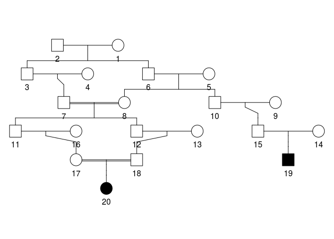

```r
plot(samplePedigrees$twoGenerationsInbreeding)
```

```r
ComputeKinshipPropCoef(samplePedigrees$twoGenerationsInbreeding)
```

```
##            [,1]       [,2]
## [1,]         NA 0.03515625
## [2,] 0.03515625         NA
```

# 5 Using Monte Carlo Simulation

*RVsharing* also allows for estimating sharing probabilities through monte carlo simulation. The primary use of this feature is for calculating sharing probabilities under non standard assumptions about the founders. However, this feature is available for the standard assumptions as well. To run a monte carlo simulation, specify all parameters as normal and additionally provide the *nSim* parameter specifying how many simulations should be run.

## 5.1 Standard Sharing Probabilties

```r
p <- RVsharing(samplePedigrees$firstCousinPair)
```

```
## Probability subjects 7 8 among 7 8 share a rare variant: 0.0667
```

```r
p <- RVsharing(samplePedigrees$firstCousinPair, nSim=1e4)
```

```
## Probability subjects 7 8 among 7 8 share a rare variant: 0.066
```

```r
p <- RVsharing(samplePedigrees$firstCousinPair, alleleFreq=0.01)
```

```
## Probability subjects 7 8 among 7 8 share a rare variant: 0.0763
```

```r
p <- RVsharing(samplePedigrees$firstCousinPair, alleleFreq=0.01, nSim=1e4)
```

```
## Probability subjects 7 8 among 7 8 share a rare variant: 0.0831
```

```r
p <- RVsharing(samplePedigrees$firstCousinPair, kinshipCoeff=0.05)
```

```
## Probability subjects 7 8 among 7 8 share a rare variant: 0.1439
```

```r
p <- RVsharing(samplePedigrees$firstCousinPair, kinshipCoeff=0.05, nSim=1e4)
```

```
## Probability subjects 7 8 among 7 8 share a rare variant: 0.1275
```

## 5.2 Custom Founder Distributions

This method allows for more complex relationships among the founders to be given. *RVsharing* allows for a complete distribution among the founders to be passed in as the parameter *founderDist*. This function should accept a single argument, N, and should return a vector of length N with values in {0,1,2} representing the number of copies of the variant each founder has.

```r
fDist <- function(N) sample(c(rep(0,N-1), 1)) # assumption that 1 founder introduces
RVsharing(samplePedigrees$firstCousinPair, nSim=1e4, founderDist=fDist)
```

```
## Probability subjects 7 8 among 7 8 share a rare variant: 0.0722
```

```
## [1] 0.07220913
```

```r
RVsharing(samplePedigrees$firstCousinPair)
```

```
## Probability subjects 7 8 among 7 8 share a rare variant: 0.0667
```

```
## [1] 0.06666667
```

# 6 Calculating Sharing Probabilties Across Multiple Families

For variants seen in only one family, the sharing probability can be interpreted directly as a P-value from a Bernoulli trial. For variants seen in M families and shared by affected relatives in a subset S of them, the P-value can be obtained as the sum of the probability of events as (or more) extreme as the observed sharing in the family subset S. The function *multipleFamilyPValue* takes a vector of sharing probabilities and a vector of TRUE/FALSE describing whether or not the variant was shared among the carriers.

```r
probs <- sapply(samplePedigrees, function(p) suppressMessages(RVsharing(p)))
observed <- c(F,F,F,T,T,F,F,F)
multipleFamilyPValue(probs, observed)
```

```
## [1] 0.0001604696
```

# References

Bureau, A., S. Younkin, M. Parker, J. Bailey-Wilson, M. Marazita, J. Murray, E. Mangold, H. Albacha-Hejazi, T. Beaty, and I. Ruczinski. 2014. “Inferring Rare Disease Risk Variants Based on Exact Probabilities of Sharing by Multiple Affected Relatives.” *Bioinformatics* 30 (15): 2189–96.

Therneau, T., S. Daniel, J. Sinnwell, and E. Atkinson. 2015. “Kinship2: Pedigree Functions.” *CRAN*. https://cran.r-project.org/package=kinship2.